# CAncer bioMarker Prediction Pipeline 2 (CAMPP2)

Abstract

The CAncer bioMarker Prediction Pipeline 2 (CAMPP2) is a R package designed to be submitted to Bioconductor. It is a tool for downstream analyses which is agnostic with respect to the source of -omics biological data. It requires that data quantification has been carried out before using the data as inputs in the pipeline. The pipeline is versatile and the functions or part of them can be used for analysis of a variety of quantitative biological data from high throughput platforms, including genes, proteins, small RNAs, lipids and glycans. CAMPP2 currently supports; differential expression/abundance analysis, LASSO/Elastic Net regression,Weighed Gene Co-expression Network Analysis, Correlation analysis and Survival analysis (Cox proportional hazard regression).

# About CAMPP (TO BE EDITED)

The pipeline can perform the following types of analysis (|) Differential expression/abundance analysis (limma [26]), (II) LASSO/Elastic-Net regression (glmnet [12]), (III) Weighed Gene Co-expression Network Analysis (WGCNA [23]), (IV) Correlation analysis (Pearson/Spearman), (V) Survival analysis (Cox proportional hazard regression, survcomp [29]) and (VI) protein-protein/gene-miRNA interaction network analysis (multimiR [27] and the STRING [20]). In addition to different types of analysis the pipeline performs missing value imputation, normalization and transformation, along with data distributional checks. Differential expression/abundance analysis can be performed with as few as 3 biological replicates in each group, whereas LASSO/Elastic-Net regression, WGCNA, correlation and survival analysis is only advisable with a large(r) number of samples. CAMPP may be run with a variety of biological molecules (genes, miRNAs, proteins etc.) from various platforms (high-throughput sequencing, microarray data, liquid chromatography–mass spectrometry, etc.). For differential expression/abundance analysis the limma package [26] for R is utilized. Though limma was originally designed for microarray data, and more recently RNAseq, a number of studies have shown the versatility of this software for the analysis of other -omics data [4, 21, 24]. LIMMA has few underlying statistical assumptions and is known to be powerful for small sample sizes as a result of shrinkage of feature-specific variances [31].

Survival (over-all, relapse-free) of patients based on the abundance/expression of a given marker is predicted using cox proportional-hazard model. Check for proportional hazard and linearity of continuous covariates are automatically performed. If the user wants to correct for confounders, such as patient age at diagnosis, drug treatment, etc., these may be included in the model.

N.B For every parameter added to the model more events are needed for appropriate statistical power. A rule of thumb is10 events for each parameter, however, this will somewhat depend on the number of levels within a given parameter. Generally results of the survival analysis should be interpreted with caution as the pipeline is unable to account for all possible options and assumptions related to this type of analysis. The check for proportional hazard and linearity of continuous covariates should be OK before interpreting any results!

# Requirements

To run CAMPP2, a working R version 4.0.0 (or newer) is required.

The Pipeline relies on a variety of R-packages which are installed during CAMPP2 installation.

List of dependencies: (KEEP THIS? if yes, needs to be updated)

| Analysis Packages |  |
| --- | --- |
| Missing value imputation | impute (v 1.56.0) [17] |
| Distributional checks | fitdistrplus (v 1.0.11) [8] |
| Excel formatting | openxlsx (v 4.1.0) [34] |
| Plotting | heatmap.plus (v 1.3), squash (v 1.0.8), viridis (v 0.5.1), ggplot2 (v 3.1.0), [7, 11, 14, 35] |
| Data management | data.table (v 1.11.8), stackoverflow (v 0.1.2), plyr (v 1.8.4), scales (v 1.0.0) [9, 13, 36, 37] |
| K-means Clustering | mclust (v 5.4.3) [30] |
| DE/DA Analysis | sva (v 3.30.0), limma (v 3.38.2) [19, 26] |
| LASSO/Elastic-Net | glmnet (v 2.0.16) [12] |
| Co-expression analysis | WGCNA (v 1.66) [23] |
| Interaction Networks | igraph (v 1.2.4), biomaRt (v 2.38.0), multiMiR (v 1.4.0), devtools (v 2.0.1), [6, 10, 27, 38] |
| Survival analysis | survminer (v 0.4.3), survcomp (v 1.32.0), [22, 29] |

# Running CAMPP2

## Example data

The test data include 2 BRCA datasets (campp2_brca_1, campp2_brca_2) and associated metadata (campp2_brca_1_meta, campp2_brca_2_meta). Each dataset is represented by raw read counts (10000 genes) for 30 samples: 20 tumours which are divided into 4 subtypes (each subtype has 5 samples), and 10 normals. Metadata includes information about diagnosis, age, vital status, days to death, outcome time, tumor stage, subtyte, outcome and survival.

Both, raw read counts and metadata were extracted from TCGA-BRCA Level 3.

Test data are integrated into CAMPP2 package and accessible as campp2_brca_1, campp2_brca_2, campp2_brca_1_meta, campp2_brca_2_meta variables once the package is installed. R data object files (.rda) are also available on https://github.com/ELELAB/CAMPP2/tree/main/data.

## Running example script

##Load CAMPP2 package:

```
library(CAMPP2)
```

##Test data are already part of the CAMPP2 package so user doesn’t need to download them. In case you want to load .rda objects manually from the cloned repository, you can use this code:

```
load("./data/campp2_brca_1.rda")
load("./data/campp2_brca_1_meta.rda")
load("./data/campp2_brca_2.rda")
load("./data/campp2_brca_2_meta.rda")
```

##Run CAMPP2 on example data with default settings:

```
runCampp2(batches=c("tumor_stage","tumor_stage"), prefix="test_CAMPP2",
data1=campp2_brca_1, data2=campp2_brca_2, metadata1=campp2_brca_1_meta,
metadata2=campp2_brca_2_meta, groups=c("IDs", "diagnosis","IDs", "diagnosis"),
technology=c("seq","seq"))
```

## Mandatory Input and Parameters

**data1**: Gene count matrix (gene IDs as row names and sample IDs as columns). It is recommended to import gene counts using function “import_counts”.

**metadata1**: Samples’ metadata table should be imported using function “import_metadata”. Metadata must include exactly the same samples as gene counts (data1) and samples must be sorted similarly.

**technology**: Technology used for the analysis of biological input. Current options are ‘array’, ‘seq’, ‘ms’ or ‘other’. This argument is mandatory and depending on which option is chosen, data is transformed differently. If a second dataset is provided, the option should be specified for each dataset, provided as a character vector.

**groups**: Argument defining groups of samples should be specified as a character vector. The first element specifying the name of the column in the metadata file containing sample IDs and the second element specifying the name of the column which contains the groups for the DE/DA analysis.

## Optional arguments

**data2**: Gene count matrix for a second dataset.

**metadata2**: Metadata for a second dataset.

**data.check**: Distributional checks of the input data is activated using logical argument (TRUE/FALSE). If activated, Cullen-Frey graphs will be made for 10 randomly selected variables to check data distributions. This argument is per default set to TRUE.

**batches**: Specifies which metadata should be used for a batch correction (sequencing run/tissue/interstitial fluid/etc.). Argument takes a character vector of length 1 (one dataset) or 2 (two datasets), where the string(s) match a column name(s) in the metadata file(s). Default is NULL.

**kmeans**: Argument for kmeans clustering. The parameter must be specified as a character vector matching the name of a column in the metadata file, denoting the labeling of points on the MDS plot(s). If a parameter is set to “TRUE” (no column name specified) no labels will be added to the plot. Works only for the first dataset (data1). Default is FALSE (do not run).

**plot.heatmap**: Argument for heatmap specified as either: “DE”, “DA”, “LASSO”, “EN” or “Consensus”. Defaults is FALSE (do not run).

**correlation**: Argument for correlation analysis. String specify which features should be correlated, options are: “ALL”, “DE”, “DA”, “LASSO”, “EN” or “Consensus”. For this type of analysis, 2 datasets must include the same samples, e.g. tumor1-normal vs tumor2-normal (3 samples from 1 patient needed). Default is FALSE (do not run).

**survival**: (double check this when parsin survival function) Survival analysis may be performed on differentially expressed/abundant variables, variables from LASSO/EN regression or the consensus of these. Argument “survival” must be specified as either; “DE”, “DA”, “LASSO”, “EN” or “Consensus”. The full dataframe of variables may be used (if argument is set to ALL), HOWEVER this is not advisable unless the dataset is small with very few variables. At least, “survival”, “outcome”, “outcome.time” info must be included in the metadata file. The metadata file must contain at least four columns named; “ids” (sample identifiers), “age” (age in years at diagnosis, surgery or entry into trail), “outcome.time” (time until end of follow-up in weeks, months or years, censuring, death) and “outcome” (numeric 0 = censuring, 1=death). N.B. in case of (paired) normal samples the columns with survival information for these samples should contain “NA” values.

**surv.plot**: Argument which specifies number of features to include per survival plot. Default is 50.

**standardize**: (double check for sequencing) Data centering. This option may be set to “mean” or “median.” If two datasets are provided, the standardize option should be specified for each dataset, provided as a character vector. If the argument standardize is not specified and “technology” = “array”, then quantile normalization will be performed. Defaults is FALSE (do not run).

**transform**: Data transformation type. Current options are “log2”, “log10”, “logit” and “voom”. If two datasets are provided the parameter should be specified for each dataset, provided as a character vector. Defaults is FALSE (do not run).

**prefix**: Prefix for the results’ files and results folder. Defalt is “Results”.

**signif**: Cut-offs for log fold change (logFC) and corrected p-value (fdr), defining significant hits (proteins, genes, miRNAs or N-features). If argument is set, it must be a numeric vector, where the first element specifies the cut-off for logFC and the second element specifies the cut-off for corrected p-value (fdr). In case of 2 datasets, vector must be of length 4. By default, cutoffs will be set to -1 > logFC > 1 and corrected p-values < 0.05.

**plot.PCA**: Argument specifies (“TRUE” or “FALSE”) if a preliminary plot should be made for data overview. Default is FALSE (do not run).

**show.PCA.labels** a boolean value (TRUE or FALSE) specifying if elements (e.g. samples) should be labelled (for PCAPlot and runKmeans functions). Labeling is based on column names of the input data. Default value is FALSE.

**covariates**: Covariates to include in the analysis. If multiple of these, they should be specified as a character vector. The first element in this list must be either TRUE or FALSE. If TRUE is specified then covariates will be included in both DE/DA analysis and Survival Analsysis. If FALSE is specified covariates will ONLY be used for Survival Analsysis. Names of covariates should match the desired columns in the metadata file. Default is NULL.

**stratify**: This argument may be used if some of the categorical (NOT continous) covariates violate the cox proportional assumption. The workflow checks for proportional hazard and will retun the covariates that fail the PH test. You may then rerun the workflow with this argument followed by the names of the categorical covariates which failed and these will be stratified. Default is NULL.

**colors**: Custom color pallet for PCA and heatmaps. Must be the same length as number of groups used for comparison (e.g. two groups = two colors) and must be defined as character vector. See R site for avalibe colors http://www.stat.columbia.edu/~tzheng/files/Rcolor.pdf. Default is NULL.

**block**: A vector or factor specifying a blocking variable for differential expression analysis. The block must be of same length as the belonging dataset and contain 2 or more options. For 2 datasets the block can be defined as a list of factors or vectors.

**lasso**: Argument specifying parameters for LASSO or Elastic net regression. This argument may be set to 1 for LASSO or >0 & <1 for Elastic Net, but NOT to 0 exactly (Ridge Regression). Defaults is FALSE (do not run).

**WGCNA**: Argument specifying parameter for Weighed Gene Co-expression Network Analysis. It takes a string, either “DA”, “DE” or “ALL” specifying if all variables should be included in WGCNA or only differentially expressed / abundant variables. Defaults is FALSE (do not run).

**cutoff.WGCNA**: Argument specifying the cutoff values for WGCNA. The argument takes a numuric vector of three values: (I) minimum modules size, (II) maximum percentage of dissimilarity for merging of modules, and (III) percentage of top most interconnected genes (or other features) to return, from each modules identified in the Weighed Gene Co-expression Network Analysis. Default values are 10,25,25.

**PPint**: Argument specifying that protein-protein interaction networks should be generated using the results of the differential expression analysis. This argument must be a character vector of length two. The first element in this list must be a string specifying the type of gene identifier in the gene counts file provided. Allowed identifiers are: “ensembl_peptide_id”, “hgnc_symbol”, “ensembl_gene_id”, “ensembl_transcript_id”, “uniprotswissprot”. The second element is a string specifying version of the stringDB to use. Currently only version supported is: 11.0. Default is FALSE (do not run).

**gene.miR.int**: Argument specifying that gene-miRNA interaction networks should be generated using the results of the differential expression analysis. This argument must be a character vector of length two. The first element in this list must be a string specifying the type of miRNA identifier in the gene counts data file. Allowed identifiers are: “mature_mirna_ids”, “mature_mirna_accession”. The second element must be a string specifying the miRNA-gene database to use, currently options are: “targetscan” (validated miRNAs), “mirtarbase” (predicted miRNAs), “tarscanbase” (validated + predicted miRNAs)“. Default is FALSE (do not run).

## FUNCTIONS IN CAMPP2

### ReplaceNAs

**Description:**  
In summary, this function removes samples and features with a high percentage of NA values. The rest of NA values is replaced by imputed values.  
In the first step of this function, percentages of NAs in rows (features) and columns (samples) are calculated. The features and samples with a high percentage of NAs are removed (by default, features having >70% and samples having >80% of NAs are removed). Remaining NA values are replaced by imputed values generated by “local least squares (llsImpute)“. If the first round of missing values imputation failed or resulted in negative values, an additional missing value imputation using impute.knn will be performed (rows with more than 50% missing values will be imputed using the overall mean per sample).  
**Parameters:**  
*data*: a dataframe of gene/abundance counts.  
*pct.NA.row*: a number defining maximal percentage of NA values present in a feature (e.g. a percentage of samples having NA in a given gene). Features (rows) with a higher percentage of NA values will be removed (70 by default).  
*pct.NA.column*: a number defining maximal percentage of NA values present in a sample (e.g. a percentage of genes having NA in one sample). Samples (columns) with a higher percentage of NA values will be removed (80 by default).  
**Output from the function:**  
A data frame without NA values  
**An example run:**  
##Each of the CAMPP2 example datasets (2) has 10000 genes and all of them have assigned read counts. In our example, we will randomly introduce 1000 NA values into each sample’s genes (taking dataset campp2_brca_1) in the first step in order to prepare test data for NA values replacement. In the next step, NA values will be replaced by calling ReplaceNAs function.

```
library(CAMPP2)
```

##Test data are already part of the CAMPP2 package so user doesn’t need to download them. In case you want to load .rda objects manually from the cloned repository, you can use this code:

```
load("./data/campp2_brca_1.rda")
load("./data/campp2_brca_1_meta.rda")
load("./data/campp2_brca_2.rda")
load("./data/campp2_brca_2_meta.rda")
```

##get a number of genes in the dataset.

```
n<-nrow(campp2_brca_1)
```

##For testing of this function, 1000 genes is assegned with NA value. NA values are introduced randomly into each sample and all the 10000 genes (n=10000) are considered for the introduction of NA values.

```
campp2_brca_1_NAs<-apply (campp2_brca_1, 2, function(x) {x[sample( c(1:n), floor(n/10))] <- NA; x} )
```

##create an object with replaced NAs; features having “NA” in more than 70% of the samples will be removed; samples having “NA” in more than 80% of the genes will be removed

```
campp2_brca_1_replacedNAs<-ReplaceNAs(data=campp2_brca_1_NAs, pct.NA.row=70, pct.NA.column=80)
```

### FixZeros

**Description:**  
This function detects zero/negative values and replaces zero values in the data. In the first step, the function checks for the presence of zero and negative values in the data. In the second step, (activated by default), features having sum of zero counts higher than the size of the smallest sample group will be removed (e.g. genes represented by zero counts/transcripts in more than n samples will be removed; n = size of the smallest group). Next, remaining zeros are substituted with minimal values (>0) observed in each feature across all samples in the dataset.  
**Parameters:**  
*data* a dataframe of gene/abundance counts.  
*group* group a factor specifying group for each sample (e.g. could be represented by a column from a metadata file).  
*remove.sparse.features* a logical argument (TRUE/FALSE) for removal of features with sum of zero counts larger than the size of the smallest sample group, and for replacing the remaining zeros. Default is TRUE.  
**Output from the function:**  
a data frame with fixed zeros. Features having sum of zero counts higher than the size of the smallest sample group are removed and remaining zeros are replaced by default.  
**An example run:**  
##Create an object with fixed zeros:

```
###Dataset without NA values ("campp2_brca_1_replacedNAs" generated in a previous step) is used as an input.
campp2_brca_1_zeroFix<-FixZeros(data=campp2_brca_1_replacedNAs,group=campp2_brca_1_meta$diagnosis, remove.sparse.features=TRUE)
```

### NormalizeData

**Description:**  
This function normalizes and transforms feature counts depending on data types (“seq”, “array”, “ms”, “other”) and selected normalization/standardization methods. Transformation methods include options for “log2”, “logit” and “log10.” If technology is “seq”, a Voom transform is applied automatically. Standardization methods options include “mean” or “median”. If technology is “seq” or “array”, this option is ignored, instead, sequencing data are normalized by “TMM”; micro-arrays data are normalized by “quantile” standardization.  
**Parameters:**  
*data* a dataframe of expression/abundance counts  
*group* a factor specifying group for each sample (e.g. could be represented by a column from a metadata file)  
*transform* a string vector of length 1 defining transformation type (“log2”, “logit”, “log10”). If technology is “seq”, this option is ignored a Voom transform is applied.  
*standardize* a string vector of length 1 defining standardization method (“mean” or “median”). If technology is “seq” or “array”, this option is ignored, instead, seq data are normalized by “TMM”; array data are normalized by “quantile” standardization.  
*technology* a string vector of length 1 defining technology used for generating the data. Allowed types are: “array”, “seq”, “ms” or “other”.  
**Output from the function:**  
an Elist (“seq” technology) or array (“array”, “ms”, “other” technologies) of normalized and transformed feature counts data  
**An example run:**  
##Create an object with normalized gene counts

```
###Dataset without zero values ("campp2_brca_1_zeroFix" generated in the previous step) is used as an input.
campp2_brca_1_normalized<-NormalizeData(data=campp2_brca_1_zeroFix,group=campp2_brca_1_meta$diagnosis,standardize="TMM",transform="voom",technology="seq")
```

### BatchCorrect

**Description:**  
This function removes batch effects (using ComBat function) which could be causing a significant heterogeneity across batches of data. Batch corrected data are intended for explanatory purposes, NOT for a DEA analysis.  
**Parameters:**  
*data* an Elist (“seq” technology) or a matrix (“array”, “ms”, “other” technologies) of normalized and transformed feature (e.g. gene) counts data  
*batch* a factor specifying batch for each sample (e.g. could be represented by a column from a metadata file)  
*group* a factor specifying group for each sample (e.g. could be represented by a column from a metadata file)  
*technology* a string vector of length 1 defining technology used for generating the data. Allowed types are: “array”, “seq”, “ms” or “other”  
**Output from the function:**  
a list including matrix (array) of batch corrected feature counts  
**An example run:**  
##Create an object with batch corrected feature (gene) counts

```
###Normalized data ("campp2_brca_1_normalized" generated in a previous step) are used as an input.
campp2_brca_1_batchCorrected<-BatchCorrect(data=campp2_brca_1_normalized,batch=campp2_brca_1_meta$tumor_stage,group=campp2_brca_1_meta$diagnosis,technology="seq")
```

### FitDistributions

**Description:**  
A function for fitting data distribution. Depending on character of the data, various distributions are calculated. In case of only integer numbers present in the dataset, poison and normal distributions are tested. In case of presence of float values in the dataset, Weibull, gamma, log normal and normal distributions are tested. In case of negative float values, only normal distribution is calculated.  
**Parameters:**  
*data* a data frame of feature counts. Only a subset of features should be input, not intended for the full feature count matrix! **Output from the function:**  
a list of the results from fitdist function describing distribution of the data  
**An example run:**  
##Create an object with information about the data distribution

[output not shown]

### PlotDistributions

**Description:**  
Plotting the feature counts’ Distributions. As results, multiple plots are obtained for each feature: 1) Cullen and Frey graph 2) Histogram and theoretical densities 3) Empirical and theoretical CDFs 4) Q−Q plot 5) P−P plot

For some of the figures, plotted distributions depends on the characteristics of the input data: In case of only integer numbers are present in the dataset, poison and normal distributions are tested. In case of presence of float values, Weibull, gamma, log normal and normal distributions are tested. In case of negative float values, only normal distribution is calculated. Resulting figures are saved into the .pdf file.

**Parameters:**  
*data* a data.frame of feature counts, the same which was used as an input for “FitDistributions” function.  
*fitted.data* a list of distribution descriptions obtained as an output from the function “FitDistributions” where the same feature counts are used as an input.  
**Output from the function:**  
a .pdf file including multiple plots: 1) Cullen and Frey graph 2) Histogram and theoretical densities 3) Empirical and theoretical CDFs 4) Q−Q plot 5) P−P plot  
**An example run:**  
##Plot distributions of the first 10 features from example batch corrected data.

[output not shown]

### MeanCounts

**Description:**  
A function for obtaining an average feature counts and SD for each gene across all the samples and for each sample group. Results are provided in a form of a list of data frames and figures which are exported into .pdf.  
**Parameters:**  
*data* a data frame of feature counts.  
*group* a factor specifying group for each sample (e.g. could be represented by a column from a metadata file)  
**Output from the function:**  
a list of data frames (for each sample group) describing mean and SD for all sample groups and also for each group of samples.  
Results are visualized via graphs saved into current directory as pdf files.  
**An example run:**  
##Run MeanCounts on object with batch corrected feature (gene) counts

```
###Normalized and batch corrected data ("campp2_brca_1_batchCorrected" generated in a previous step) are used as an input.
meanCounts(campp2_brca_1_batchCorrected, campp2_brca_1_meta$diagnosis)
```

### PCAPlot

**Description:**  
A function calculating Principal component analysis (PCA). PCA is a method for dimensionality reduction. PCA plot shows the relationships between samples (based on squared euclidean distances) in the data set. Each dot represents one sample. This function provides also a scree plot describing percentages of explained variances by each principal component and plots with contributions of variables (e.g. genes) to PC1 and PC2.  
**Parameters:**  
*data* a dataframe of expression/abundance counts  
*group* a factor specifying group for each sample (e.g. could be represented by a column from a metadata file)  
*cols* a vector of colors (one color for each group)  
*show.PCA.labels* a boolean value (TRUE or FALSE) specifying if elements (e.g. samples) should be labelled. Labeling is based on column names of the input data. Default value is FALSE.  
**Output from the function:**  
1) scree plot  
2) contributions of variables to PC1  
3) contributions of variables to PC2  
4) 2D PCA plot (projections of the samples on the first 2 principal components)  
**An example run:**  
##Run PCA on object with batch corrected feature (gene) counts

```
###Normalized and batch corrected data ("campp2_brca_1_batchCorrected" generated in a previous step) are used as an input.
PCAPlot(campp2_brca_1_batchCorrected, as.factor(campp2_brca_1_meta$subtype), show.PCA.labels=FALSE, cols=NULL, prefix="test_PCA_plot")
```

### runKmeans

**Description:**  
A wrapper function for K-means clustering. In a first step, a number of clusters is estimated. By default, for data sets with >1000 features, multiple subsets (number of sets = number of features/1000; rounded up to the higher integer) will be generated, maximum is 10 sub-sets. A number of randomly selected features (e.g. genes) in 1 subset is limited to 2000. The values for number of subsets and size of the sub-sets might by defined manually. The option of using the whole dataset for the estimation of the number of the clusters is also available. By default, a number of clusters for each sub-set is automatically estimated (using mclustBIC function from mclust package) and a consensus (based on all the subsets) of best n k-means is returned and used for K-means clustering. If K-means estimation using BIC fails, a number of clusters will be based on the number of samples (2-6 clusters for data set with less than 100 samples; 2-11 for data sets with 101-500 samples, and 2-16 clusters for data sets with more than 500 samples). The number of clusters can also be supplied manually. In the next step, K-means clustering using the information about the number of clusters is done. As results, an information about the clusters assigned to each sample and results from PCA (FactoMineR) function are provided. The clusters are visualized on PCA plot and saved into .png file. Plot of BIC values for each of the sample sub-set is saved into .png file. A summary describing the best model is printed on the screen during calculation.  
**Parameters:**  
*data* a data.frame of feature (e.g. gene) counts  
*num.subsets* a number of sub-sets to be generated for the estimation of the number of clusters. This parameter has several options: 1) a numeric (integer) value estimated by the user. 2) a string “automatic” will let CAMPP2 estimate the number of the sub-sets. 3) NULL option will use the whole set for the estimation of the number of clusters. If using this option, subset.size must be also NULL. Defaults is NULL.  
*subset.size* a number of features included in each sub-set. This parameter has several options: 1) a numeric (integer) value estimated by the user. 2) a string “automatic” will let CAMPP2 estimate the size of the sub-sets. 3) NULL option will use all the features (no sub-sampling) for the estimation of the number of clusters. If using this option, num.subsets must be also NULL. Defaults is “automatic”  
*show.PCA.labels* s a boolean value (TRUE or FALSE) specifying if elements (e.g. samples) should be labelled in the PCA plot including information about the clusters. Labeling is based on column names of the input data. Default value is FALSE.  
*colors* a vector of colors (one color for each cluster)  
*prefix* a character string defining a prefix of output file.  
*num.km.clusters* a vector of numbers of clusters expected in the data. Clusters can be represented e.g., by sample groups, sub-types, etc. If multiple values provided, the function will automatically perform K-means clustering based on each (expected number of clusters) of them separately. By default, expected numbers of clusters are calculated automatically based on BIC (mclust package) applied to sub-sampled data sets. A default value for this parameter is NULL.  
*seed* a number for setting a random seed. If the argument is NULL, the seed won’t be set. Default is NULL.  
*pca.scale* a boolean, if TRUE then data are scaled to unit variance during PCA. Default is FALSE  
**Output from the function:**  
1) a list including:  
a) a data.frame with cluster information assigned to each sample;  
b) a PCA object including data for generating PCA plots with cluster  
information (generated by PCA function from FactoMineR package);  
2) 2D PCA plot(s) projecting samples (labeled with cluster number) over first 2 principal components saved into .png. 3) plots of BIC values for each sample sub-set saved into .png file

**An example run:**

##Estimate number of K-means and assign a specific cluster to each sample

```
###Normalized and batch corrected data ("campp2_brca_1_batchCorrected" generated in a previous step) are used as an input.
Kmeans.output<-runKmeans(campp2_brca_1_batchCorrected[1:2000,], num.subsets= NULL, subset.size=NULL, show.PCA.labels = FALSE, colors=NULL, prefix="test", num.km.clusters=NULL, seed=123, pca.scale=FALSE)
```

### EstimateKmeans

**Description:**  
A function to estimate the number of K-means. A Number of K-means is based on the Bayesian information criterion (BIC) provided by mclust package. A summary describing the best model is printed on the screen during the calculation.  
**Parameters:**  
*data* a data.frame of feature (e.g. gene) counts  
**Output from the function:**  
a data frame with the number of clusters  
**An example run:**  
##Estimate number of K-means

```
###Sub-sampled (the first 2000 genes) normalized and batch corrected data ("campp2_brca_1_batchCorrected" generated before) are used as an input.
EstimateKmeans(t(campp2_brca_1_batchCorrected[1:2000,]))
```

### RunDEA

```
campp2_brca_1_DEA<-RunDEA(data=campp2_brca_1_normalized,
metadata=campp2_brca_1_meta,
group=campp2_brca_1_meta$subtype, prefix="test",
block=campp2_brca_1_meta$subtype, batch=campp2_brca_1_meta$age,
covarDEA = c("tumor_stage"), cutoff.logFC=1, cutoff.FDR=0.01)
```

### DEAFeatureApply

**Description:**  
A function for applying differential expression/abundance analysis to all group comparisons at once. The analysis is based on feature counts (e.g., genes), design matrix and contrast matrix. Cutoffs for logFC and FDR; and blocking variable are optional. Using parameter vector=TRUE, only features’ IDs are output.  
**Parameters:**  
*data* a matrix of (transformed and normalized) feature counts from “seq”, “array”, “ms” or “other” technology (with feature IDs as row names and sample IDs as columns).  
*design.matrix* a design matrix based on samples metadata (groups, covariates, etc.).  
*contrast.matrix* an array containing contrast.matrix between groups of interest.  
*cutoff.logFC* A cutoff value for the logarithmic fold change applied to each feature. Default = 1.  
*cutoff.FDR* a cutoff value for the false discovery rate (corrected p-value) applied to each feature. Default = 0.01.  
*block* a factor specifying blocking variable. The block must be of the same length as data and contain 2 or more options (e.g. could be represented by a column from a metadata file). Default = NULL.  
*vector* a boolean value. If TRUE, only a vector of unique features IDs will be output. Default = FALSE.  
**Output from the function:**  
a list (a vector in case vector=TRUE) of DEA features for all comparisons  
**An example run:**  
## Run differential gene expression on all groups comparasons

```
DEA_all_comparisons <- DEAFeatureApply(data = campp2_brca_1_normalized,
design.matrix = campp2_brca_1_DEA$DEA.design.matrix, contrast.matrix =
campp2_brca_1_DEA$DEA.contrast.matrix, cutoff.logFC =1, cutoff.FDR =0.01,
block = campp2_brca_1_meta$subtype, vector = FALSE)
```

### DEA_feature

**Description:**  
A function for applying differential expression/abundance analysis using limma. The analysis is usually based on normalized feature counts (e.g., genes), design matrix and contrast matrix (using only 1 contrast). Cutoffs for logFC and FDR; and blocking variable are optional.  
**Parameters:**  
*contrast.matrix* an array containing contrast.matrix between groups of interest.  
*data* a matrix of (transformed and normalized) feature counts from “seq”, “array”, “ms” or “other” technology (with feature IDs as row names and sample IDs as columns).  
*design.matrix* a design matrix based on samples metadata (groups, covariates, etc.).  
*cutoff.logFC* A cutoff value for the logarithmic fold change applied to each feature. Default = 1.  
*cutoff.FDR* a cutoff value for the false discovery rate (corrected p-value) applied to each feature. Default = 0.01.  
*block* a factor specifying blocking variable. The block must be of the same length as data and contain 2 or more options (e.g. could be represented by a column from a metadata file). Default = NULL.  
**Output from the function:**  
a list of up and down-regulated features in limma format  
**An example run:**  
##Run differential gene expression on the first group comparison (using 1st column from provided contrast matrix).

```
DEA_one_comparison <-
DEAFeature(contrast.matrix = campp2_brca_1_DEA$DEA.contrast.matrix[,1],
data = campp2_brca_1_normalized,
design.matrix = campp2_brca_1_DEA$DEA.design.matrix,
cutoff.logFC =1, cutoff.FDR =0.01, block = campp2_brca_1_meta$subtype)
```

### ExportDEA

**Description:**  
A function for re-formatting the output from DEA generated based on the workflow: (runDEA - DEAFeatureApply - DEAFeature - limma); and exporting the results into a .txt file.  
**Parameters:**  
*res.DEA* a list of data frames containing results from different group comparisons in limma format. *prefix* a character vector defining prefix of output file name.  
**Output from the function:**  
1) a data frame of DEA results  
2) a .txt table of exported DEA results  
**An example run:**  
##Reformat and export results from DEA generated by limma in DEA_feature function

```
campp2_brca_1_DEA_out<-ExportDEA(res.DEA = campp2_brca_1_DEA$res.DEA,
prefix="test")
```

### RunDEAVisuals

**Description:**  
This function wraps several functions for the visualisation of DEA results: 1) A function for making volcano plots from DEA results. The input is typically an output from RunDEA (re-formatted matrix of differential expression/abundance results from limma, please, check RunDEA for more details). By default, top 15 up- and down-regulated features will be labeled on the Volcano plot. Important: Features are selected from the table with all the groups’ comparisons. 2) A function for making Venn diagrams to visualize the size of intersections of the features between the groups (e.g., differentially expressed genes for each subtype) 3) A function for making Upset plots to visualize the size of intersections of the features present each group (e.g., differentially expressed genes for each subtype)  
**Parameters:**  
*data* A data frame from RunDEA containing genes and their corresponding AveExpr, logFC, p.value, adj.p.value ect. Mandatory columns are “logFC”, “adj.P.Val” and “HUGO_ID.” HUGO_ID could be obtained using AddGeneName function.  
*prefix* a prefix for the output filename.  
*cutoff.FDR* a numeric value for adj.P.Val cutoff. Default = 0.01  
*cutoff.logFC* a numeric value for logFC cutoff. Default = 1  
*n.labeled.features* a number of the most up-/down- regulated features labeled in the volcano plot. Default = 15  
*control.group* A string vector defining control group name for each dataset (e.g., “healthy” or “normal”).  
**Output from the function:** several .png files with:  
1) Volcano plot of differentially expressed features saved into .png  
2) Venn Diagram showcasing the size of intersections of the features between the sample groups  
3) Upset plot showcasing the size of intersections of the features between the sample groups  
**An example run:**  
##Create a volcano plot, venn diagram, upset plots based on results from RunDEA and AddGeneName functions.

```
RunDEAVisuals(campp2_brca_1_DEA_HUGO, cutoff.FDR = 0.01, cutoff.logFC = 1,
n.labeled.features = 15, control.group= "healthy", prefix="test_DEA_visuals")
```

### MakeVolcano

**Description:**  
A function for making volcano plots from DEA results. The input is typically an output from RunDEA (re-formatted matrix of differential expression/abundance results from limma, please, check RunDEA for more details). By default, top 15 up- and down-regulated features will be labeled on the Volcano plot. Important: Features are selected from the table with all the groups’ comparisons.  
**Parameters:**  
*data* A data frame from RunDEA containing genes and their corresponding AveExpr, logFC, p.value, adj.p.value ect. Mandatory columns are “logFC”, “adj.P.Val” and “HUGO_ID.” HUGO_ID could be obtained using AddGeneName function.  
*prefix* a prefix for the output filename  
*cutoff.FDR* a numeric value for adj.P.Val cutoff. Default = 0.01  
*cutoff.logFC* a numeric value for logFC cutoff. Default = 1  
*n.labeled.features* a number of the most up-/down- regulated features labeled in the volcano plot. Default = 15  
**Output from the function:**  
Volcano plot of differentially expressed features saved into .png  
**An example run:**  
##Create a volcano plot based on results from RunDEA and AddGeneName functions.

```
MakeVolcano(campp2_brca_1_DEA_HUGO, prefix = "test_volcano",
cutoff.logFC = 1, cutoff.FDR = 0.01, n.labeled.features = 15)
```

### MakeUpset

**Description:**  
A function for making Upset plots to visualize the size of intersections of the features present each group (e.g., differentially expressed genes for each subtype)  
**Parameters:**  
*prefix* A prefix for the output filename.  
*groups.feature.list* A list of character vectors (each character vector named by its group name, e.g., “LumA”) including feature names characteristic for each group of interest (e.g., for subtype).  
*label* a character vector used as a label for the upset plot. Default is ““.  
*label.vertical.position* a numeric value describing vertical position of the label. Default is 15.0 (cm).  
*y.axis.by* an integer describing interval used for labeling Y-axis. Defaults is 100.  
*set.size.by* an integer describing interval used for labeling the set size axis. Defaults is 200.  
**Output from the function:**  
An Upset plot showcasing the size of intersections of the features between the sample groups  
**An example run:**  
##Create an Upset plot based on a list of the features characteristic for each group

```
MakeUpset("testUpSet",campp2_brca_1_DEA_HUGO_features_per_group,
label="test_UpSet",label.vertical.position=16.5,
y.axis.by=300,set.size.by=250)
```

### MakeVennDiagram

```
MakeVennDiagram("test_Venn", campp2_brca_1_DEA_HUGO_features_per_group)
```

### RunHeatmap

**Description:**  
A function for making heatmaps to showcase the difference in expression/abundance of features across samples and sample groups and to visualise relations between them.  
**Parameters:**  
*feature.counts* a feature count matrix (ideally normalized and batch corrected) from “seq”, “array”, “ms” or “other” technology (with feature IDs as row names and sample IDs as columns). It’s recommended to import feature counts using function “import_counts”.  
*DEA.out* a data frame from RunDEA containing genes and their corresponding AveExpr, logFC, p.value, adj.p.value ect. Mandatory columns are “logFC”.  
*group* a factor specifying group for each sample (e.g. could be represented by a column from a metadata file). Group’s information will be used in clustering the samples.  
*heatmap.size* an argument specifying how many genes will be selected to be plotted on the heatmap if plot.heatmap is TRUE. The input must be specified as an even number.

```
RunHeatmap(campp2_brca_1_batchCorrected, campp2_brca_1_DEA_HUGO,
campp2_brca_1_meta$subtype, heatmap.size=30, viridis.palette="turbo",
plot.heatmap="DEA", "test_heatmap")
```

### MakeHeatmap

```
MakeHeatmap(data=campp2_brca_1_batchCorrected, group=campp2_brca_1_meta$subtype,
prefix="test_heatmap", viridis.opt = "turbo", data.type = "expression/abundance")
```

### runLASSO

**Description:**  
The function runs LASSO/Elastic net/Ridge regression (depending on a hyperparameter alpha value. For Ridge regression, alpha = 0; for Elastic net, alpha >0 & <1; for LASSO, alpha = 1). The regression is calculated 10 times for 10 random seeds and the intersect of the significant features (e.g., genes) is obtained. Parameter Lambda is automatically estimated using k-fold cross-validation (cv.glmnet) by default. The function optionally (>20 samples) calculates a double cross-validation using a validation set which represents 1/4 of the samples from each group.  
Results are provided in the form of:  
1) the names of the significant features passing filters based on their coefficient values  
2) classification error rate (datasets of >20 samples)  
3) roc.res - AUC value (datasets of >20 samples)  
4) cross validation error plot  
**Parameters:**  
*data* a data frame of expression/abundance counts. It’s recommended to use normalized and batch corrected data.  
*group* a factor specifying group for each sample (e.g. could be represented by a column from a metadata file)  
*alpha* a numeric vector specifying hyperparameter alpha. This value must be set to 0.0 < x < 1.0 for Elastic Net (0.5 is default) or to 1.0 for LASSO regression or to 0.0 for Ridge regression.  
*min.coef* a numeric vector specifying a threshold for features’ filtering (e.g. genes) based on the coefficients which are calculated during model fitting. Default value is > 0.  
*nfolds* a numeric vector describing number of folds during Lambda estimation which is based on a cross-validation. Although nfolds can be as large as the sample size (leave-one-out CV), it is not recommended for large datasets. Smallest value allowable is nfolds=3. Default is 10. *prefix* a character string defining a prefix of output file.  
**Output from the function:**  
1) VarSelect - a matrix of feature names having coefficients of best model passing the filters (threshold defined by min.coef)  
2) cv.error - logical/numeric value describing miss classification error rate (datasets of >20 samples)  
3) roc.res - AUC value (datasets of >20 samples)  
4) cross validation error plot  
**An example run:**

##Run a wrapper of Ridge/elastic net/LASSO regression

```
###Normalized and batch corrected data are used as an input for regression.
##run regression using small batch corrected dataset - no double cross validation
runLASSO(data=campp2_brca_1_batchCorrected, group=campp2_brca_1_meta$diagnosis, alpha=0.5, min.coef=0, nfolds=10, prefix="test")
##run regression using large batch corrected dataset suitable for double cross validation
###create a large dataset
campp2_test_data_LASSO<-cbind(campp2_brca_1,campp2_brca_2)
campp2_test_metadata_LASSO<-rbind(campp2_brca_1_meta, campp2_brca_2_meta)
campp2_test_data_LASSO_replaceNAs<-ReplaceNAs(data=campp2_test_data_LASSO)
campp2_test_data_LASSO_zeroFix<-FixZeros(data=campp2_test_data_LASSO_replaceNAs,group=campp2_test_metadata_LASSO$diagnosis, remove.sparse.features=TRUE)
campp2_test_data_LASSO_normalized<-NormalizeData(data=campp2_test_data_LASSO_zeroFix,group=campp2_test_metadata_LASSO$diagnosis,standardize="TMM",transform="voom",technology="seq")
campp2_test_data_LASSO_batchCorrected<-BatchCorrect(data=campp2_test_data_LASSO_normalized,batch=campp2_test_metadata_LASSO$tumor_stage,group=campp2_test_metadata_LASSO$diagnosis,technology="seq")
###run lasso on a large dataset
runLASSO(data=campp2_test_data_LASSO_batchCorrected, group=campp2_test_metadata_LASSO$diagnosis, alpha=0.5, min.coef=0, nfolds=10, prefix="test")
}
```

### LASSOFeature

**Description:**  
The function runs LASSO/Elastic net/Ridge regression (depending on a hyperparameter alpha value). Parameter Lambda is automatically estimated using k-fold cross-validation (cv.glmnet) by default. The function optionally calculates also double cross-validation using a test set. aValidation (test) set represents 1/4 of the samples from each group.  
Results are provided in the form of: 1) the ames of the signifficant features passing filters based on their coefficient values  
2) classification error rate (calculated if “validation=TRUE”)  
3) cv.glmnet object.  
**Parameters:**  
*seed* an integer vector containing the random number generator (RNG) state. Default is 123.  
*data* a data frame of expression/abundance counts. It’s recommended to use normalized and batch corrected data.  
*group* a factor specifying group for each sample (e.g. could be represented by a column from a metadata file)  
*alpha* a numeric vector specifying hyperparameter alpha. This value must be set to 0.0 < x < 1.0 for Elastic Net (0.5 is default) or to 1.0 for LASSO regression or to 0.0 for Ridge regression.  
*validation* a boolean value for performing double cross-validation. Validation (test) set represents 1/4 of the samples in each group. As a result, cross validation error rate is provided. Default value is FALSE.  
*min.coef* a numeric vector specifying a threshold for features’ filtering (e.g. genes) based on the coefficients which are calculated during model fitting. Default value is > 0.  
*nfolds* a numeric vector describing number of folds during Lambda estimation which is based on a cross-validation. Although nfolds can be as large as the sample size (leave-one-out CV), it is not recommended for large datasets. Smallest value allowable is nfolds=3. Default is 10.  
**Output from the function:**  
a list of: 1) coef.ma.names - a matrix of feature names having coefficients of best model passing the filters (threshold defined by min.coef) 2) class.error - logical/numeric value describing miss classification error rate 3) fit - cv.glmnet object  
4) coef.ma - a matrix of the features’ coefficients (best model) passing the filters (threshold defined by min.coef)  
**An example run:**

##Run Ridge/elastic net/LASSO regression

```
###Normalized and batch corrected data are used as an input for regression.
LASSOFeature(seed=123, data=campp2_brca_1_batchCorrected,
group=campp2_brca_1_meta$diagnosis, alpha=0.5, validation=TRUE,
min.coef = 0, nfolds=10)
```

### RunDEA_LASSO_consensus

**Description:**  
This function creates a consensus between the results from DEA and LASSO/Elastic net/Ridge regression. Specifically, only the features present in LASSO results are kept in the DEA results table. Additionally, a Venn diagram visualizing overlaps is generated.  
**Parameters:**  
*DEA.out* a data frame from RunDEA containing features and their corresponding AveExpr, logFC, p.value, adj.p.value ect. Mandatory column is “name”  
*LASSO.results* an object generated by runLASSO function  
*group* a factor specifying group for each sample (e.g. could be represented by a column from a metadata file)  
*viridis.palette* a character vector specifying color gradient to use for the heatmap. Default option for viridis color palettes is ‘turbo’. For more options, see viridis vignette.  
*prefix* a character string defining a prefix of output file.  
**Output from the function:**  
a list of: 1) a data frame of features common for both DEA and LASSO which are extracted from DEAout table  
2) a .png with a Venn diagram of features’ intersections between DEA and LASSO  
**An example run:**

```
##here we prepare DEA results compatible (group="diagnosis) with
EN/LASS/Ridge regression results:
campp2_brca_1_DEA_diagnosis<-RunDEA(data=campp2_brca_1_normalized,
metadata=campp2_brca_1_meta,
group=campp2_brca_1_meta$diagnosis, prefix="test", batch=campp2_brca_1_meta$age,
covarDEA = c("tumor_stage"), cutoff.logFC=1, cutoff.FDR=0.01)
##here we run RunDEA_LASSO_consensus function:
campp2_brca_1_DEA_LASSO_consensus <- RunDEA_LASSO_consensus(
campp2_brca_1_DEA_diagnosis$DEA.out,
campp2_brca_1_LASSO, group=campp2_brca_1_meta$diagnosis,
viridis.palette="turbo", "test")
```

### RunRF

**Description:**  
The function runs random forest classification and variable selection by running the RFApply function. The classification and variable selection are calculated 10 times for 10 random seeds and the intersection of the selected variables (e.g., genes) is obtained. The function optionally performs validation using a validation dataset of the random forest classification if there is enough samples in the dataset. This is determined by the split.size argument. If validation is not performed, only variable selection using random forest is carried out. The function also intersects the selected features across all 10 seed runs as found during the feature selection process.  
**Parameters:**  
*data* a matrix of (transformed and normalized) feature counts from “seq”, “array”, “ms” or “other” technology (with feature IDs as row names and sample IDs as columns). If available, batch corrected data should be used.  
*group* a factor specifying group for each sample (e.g. could be represented by a column from a metadata file).  
*split.size* an integer specifying the minimum number of samples that the groups must contain in order to carry out random forest classification and validation.  
*test.train.ratio* a floating point number between 0 and 1 representing the ratio of samples to keep as validation dataset. For example, a test.train.ratio = 0.25 splits 25 percent of the data into a validation dataset, meaning 75 percent of the data will be kept as the training dataset.  
*num.trees.init* an integer specifying number of trees to use for the first forest in the feature selection process. Default is 5000.  
*num.trees.iterat* an integer specifying number of trees to use for all additional forests in the feature selection process. Default is 2000.  
**Output from the function:**  
a list of:  
1) a list containing the output from the RFApply function.  
2) a character vector containing the intersection of selected variables (e.g., genes) from the feature selection process.  
**An example run:**

```
campp2_brca_1_run_rf <-
RunRF(data = campp2_brca_1_batchCorrected,
group = campp2_brca_1_meta$diagnosis,
split.size = 5,
test.train.ratio = 0.25,
num.trees.init = 5000,
num.trees.iterat = 2000)
```

### RFApply

**Description:**  
This function applies the ForestFeatures function using 10 random seeds. The ForestFeatures function performs random forest on feature counts (e.g. genes) and allows for feature selection using the random forest algorithm. This function extracts various results from the feature selection process such as the selected variables and the OOB errors. Moreover, the OOB error which resulted in the final selected model and the final selected variables is extracted. The final selected model is the one with the smallest number of genes whose error rate is within 1 standard error of the minimum error rate of all forests. The function also extracts results from the process of random forest fitting to the input data such as OOB error, predictions on test data and corresponding accuracies. Finally, the function calculates the average initial importance of each variable across the seed runs.  
**Parameters:**  
*data* a matrix of (transformed and normalized) feature counts from “seq”, “array”, “ms” or “other” technology (with feature IDs as row names and sample IDs as columns). If available, batch corrected data should be used.  
*group* a factor specifying group for each sample (e.g. could be represented by a column from a metadata file).  
*validation* a boolean indicating if validation will be performed on test data. If TRUE validation will be performed on test data. If FALSE validation will not be performed on test data. Default is FALSE.  
*test.train.ratio* a floating point number between 0 and 1 representing the ratio of samples to keep as validation dataset. For example, a test.train.ratio = 0.25 splits 25 percent of the data into a validation dataset, meaning 75 percent of the data will be kept as the training dataset.  
*num.trees.init* an integer specifying number of trees to use for the first forest in the feature selection process. Default is 5000.  
*num.trees.iterat* an integer specifying number of trees to use for all additional forests in the feature selection process. Default is 2000.  
**Output from the function:**  
a list of:  
1) a list where each element is a character string containing selected variables from the random forest feature selection process from each seed run.  
2) a list where each element is out-of-bag errors (of type numeric) from all random forest models used in the feature selection process for each seed run.  
3) a list where each element is the OOB error (of type numeric) from the best random forest model (i.e. the final selected model) of the feature selection process for each seed run.  
4) a matrix containing average initial importance (before any variable deletion) for each feature across seed runs.  
5) a list where each element is the OOB error (of type numeric) from fitted random forest model for each seed run (if a random forest was not fitted then this will be NA).  
6) a matrix ccontaining accuracy and 95 percent confidence interval for predictions of test data using fitted random forest model where each row in the matrix is a seed run.  
7) a vector of integers containing seeds used in the procedure.  
**An example run:**

```
campp2_brca_1_rf_apply <- RFApply(data = campp2_brca_1_batchCorrected,
group = campp2_brca_1_meta$diagnosis,
validation = TRUE,
test.train.ratio = 0.25,
num.trees.init = 5000,
num.trees.iterat = 2000)
```

### ForestFeatures

**Description:**  
This function implements random forest on feature counts (e.g. genes) and allows for feature selection using the random forest algorithm. For the feature selection process, the recommended value for number of trees is 5000 for the first forest and 2000 for all additional forests which are used as default values in this function. In the variable selection process, variables are eliminated iteratively by excluding the least important variables from each random forest. 20 percent of the variables are excluded following each iteration. The out-of-bag (OOB) error is used as criterion for determining the final selected variables. Besides variable selection, a random forest model is also fitted which is used for classification of the samples. The input data is split into training and validation datasets where the training data is used for variable selection and classification and the random forest classifier is validated on the validation dataset. Splitting of the data is determined by the test.train.ratio. For example, a test.train.ratio = 0.25 splits 25 percent of the data into a validation dataset, meaning 75 percent of the data will be kept as the training dataset.  
**Parameters:**  
*seed* an integer containing a random seed number. Default is 123.  
*data* a matrix of (transformed and normalized) feature counts from “seq”, “array”, “ms” or “other” technology (with feature IDs as row names and sample IDs as columns). If available, batch corrected data should be used.  
*group* a factor specifying group for each sample (e.g. could be represented by a column from a metadata file).  
*validation* a boolean indicating if validation will be performed on test data. If TRUE validation will be performed on test data. If FALSE validation will not be performed on test data. Default is FALSE.  
*test.train.ratio* a floating point number between 0 and 1 representing the ratio of samples to keep as validation dataset. For example, a test.train.ratio = 0.25 splits 25 percent of the data into a validation dataset, meaning 75 percent of the data will be kept as the training dataset.  
*num.trees.init* an integer specifying number of trees to use for the first forest in the feature selection process. Default is 5000.  
*num.trees.iterat* an integer specifying number of trees to use for all additional forests in the feature selection process. Default is 2000.  
**Output from the function:**  
a list of:  
1) a varSelRF object containing results of variable selection using random forest.  
2) a randomForest object random forest model fitted to data.  
3) a factor containing predictions of test data using fitted random forest model.  
4) a confusionMatrix object confusion matrix of test data using fitted random forest model.  
If validation = FALSE, the last three elements in output will be NA.  
**An example run:**

```
campp2_brca_1_forest_features <- ForestFeatures(seed = 123,
data = campp2_brca_1_batchCorrected,
group = campp2_brca_1_meta$diagnosis,
validation = TRUE,
test.train.ratio = 0.25,
num.trees.init = 5000,
num.trees.iterat = 2000)
```

================================================================================================ (THE REST WILL BE CONSIDERED - WE CAN USE SOME INFO TO BETTER DESCRIBE THE ARGUMENTS ABOVE) **1. Quantitative data (counts)** : An .xlsx (or .txt) file containing feature expression/abundance. With rows as variables, and columns as samples, e.g. columns are gene, N-glycan, protein, (mi)RNA identifiers and rows are sample IDs. The repository https://github.com/ELELAB/N-glycan-TIF/ tree/master/Data/DataExamples contains an example with N-glycans named: glycandata.xlsx. If two datasets are provided (for correlation and/or network analysis), this option should be specified as a comma separated list (without quotes or parenthesis!) of length two, first entry being data file 1 and second entry data file 2.

**2. Data type (data_type)**: The user must specify what type of data is provided in order for the pipeline to pick the appropriate normalization and/or transformation. Options include; array (mircoarray data), seq (high throughput sequencing data), ms (mass spectrometry data) or other (other type). If two datasets are provided (for correlation and/or network analysis), this option should be specified as a comma separated list (without quotes or parenthesis!) of length two, first entry referring to data file 1 and second entry referring to the data file 2.

• Sequencing data: (data type is set to seq): Variables with low counts over all groups (tissue, treatment) are filered out, library sizes are scaled (normalization method is weighted trimmed mean of M-values, TMM) and data are voom transformed. • Microarray data (data type is set to array): Data are log transformed and either quantile normalized (normalizeBetweenArrays) or standardized using mean or median (specify option -z). • Mass spectrometry data (data type is set to ms): IF option -t is specified, then data will be log transformed (log2, log or logit as specified). It should be noted that CAMPP does NOT perform within-array normalization (normalizeBetweenArrays), which is standard for two color intensity data, e.g. this must be done before hand (see limma manual for more information [26]).

**3 Metadata (metadata)**: An .xlsx file (or .txt) containing metadata. This file must contain at least two columns, one with identifiers matching the column names in the data file and one with groups to contrast in analysis e.g. diagnosis (tumor or normal), tumor stage (1,2 or 3), drug treatment (A, B C) etc. If two datasets are provided (for correlation and/or network analysis), this option should be specified as a comma separated list (without quotes or parenthesis!) of length two, first entry being metadata file 1 and second entry metadata file 2. The repository https://github.com/ELELAB/N-glycan-TIF/ tree/master/Data/DataExamples contains an example with N-glycans named: glycanmetadata.xlsx.

**4 Ids and Groups (IDs, groups)**: The user must specify which columns in the metadata file corresponds to the sample ids and groups for comparison, receptively. This is done by providing a list of two strings separated by a comma (without quotes or parenthesis!) , indicating the names of the columns which should be used. If two datasets are provided, and both datasets are to be corrected for experimental batch, this option should be specified as a comma separated list (without quotes or parenthesis!) of length four. The first two entries in the list specifying names of columns (IDs and groups) to use from metadataset 1 and third and fourth entry specifying names of columns (ids and groups) to use from metadataset 2.

## Other Arguments

**Data Transformation** (transform): The flag -t may be set if the user desires the expression/abundance data to be transformed before analysis. A logarithmic transformation is recommended as the variance of measurements, from most platforms, depend on the expression/abundance level itself. The log-transformation reduces this dependency and additionally pushes the negative binomial distribution, displayed by count data (miRNA, mRNA), towards a normal distribution. The user may choose between log2, log10, logit or voom tranformation. For RNA-seq the voom transformation is recommended [26], while a log transformation may be more appropriate for proteomics and N-glycan abundances. If another sample paired dataset of expression values are provided, this option should be specified as a comma separated list (without quotes or parenthesis!) of length two, first entry referring to data file 1 and second entry referring to the data file 2.

**Batch** (batch): If the data comes from experimental batches and the user wants to correct for this, a column specifying which batch each sample belongs, should also be included in the metadata file. The argument “batch” takes a string (no quotes!) referring to the name of the column in the metadata file denoting batches (e.g. A, B, C, or batch1, batch2, batch3, etc.). Batch type must be noted as a character, meaning **numbers alone are not allowed**. If two datasets are provided, this option should be specified as a comma separated list (without quotes or parenthesis!) of length two, first entry matching the name of a column in metadata file 1 and the second entry matching the of a column in metadataset 2.

**Distibutional Checks** (check_distr): this argument may be set to FALSE to remove the default check of variable distributions. If the argument is not specified (or set to TRUE), the pipeline will produce plots including histograms, quantile-quantile plots and probability plots. By default 10 random variables are picked from the dataframe for plotting (here we are assuming that most variables in an gene expression matrix or protein abundance matrix will belong to the same family of distributions.) We heavily recommend always running the data checks and to NOT ignore the output, as this vital to whether or not results are reliable!.

**Colors** (colors): An argument to change group color scheme. Accepted Rcolors must be specified in a comma separated list (without parenthesis!) of a length matching the number of groups.

**Covariates** (covars): The user may specify argument “covars” if covariates should be included in the differential expression/abundance analysis and/or the survival analysis. This argument takes a comma separated list (without quotes or parenthesis!). The first element in this list must be either TRUE or FALSE. If TRUE is specified then covariates will be included in both DE/DA analysis and Survival Analsysis. If FALSE is specified covariates will ONLY be used for Survival Analsysis. All other elements of the list after element one (TRUE/FALSE) must be strings matching one or more column names in the metadata file. Age is automatically added as a covariate for survival anlysis and should therefore not be specified with “covars”!

**LogFC and FDR** (logFC_FDR): Cut-offs for log2 fold change and corrected p-value (fdr). Defaults are logFC > 1 or logFC < -1 and fdr < 0.05. This argument takes a comma separated list of length two (without quotes or parenthesis!). The first element specifying cut-off for logFC and the second element specifying cut-off for FDR. If two datasets are provided, the list must have length four, e.g. cut-offs for both sets.

**LASSO/Elastic-Net Regression** (LA_EN): The argument “LA_EN” may be set to specify least absolute shrinkage and selection operator (LA_EN 1.0) or Elastic-Net (0.0 < LA_EN < 1.0) regression. LASSO/EN is performed using the R-package glmnet [12]. K-fold (default is 10) cross validation (cv.glmnet) is used to estimate the optimal value for the hyperparameter, lambda. LASSO/EN may be performed in two ways, (I) the dataset is split into training and testing subsets, k-fold cross validation is performed on the training dataset, followed by estimation of specificity and sensitivity (area under the curve = AUC) using the test dataset, or (Il) k-fold cross validation is performed using the full dataset, no AUC is reported. CAMPP will automatically estimate whether the input dataset is large enough to split into training and test subsets and whether EN/LASSO is advisable to perform altogether. Specifying the argument LA_EN will produce a list of variables selected by LASSO and a file with the overlap between differential expression/abundance analysis and LASSO regression. LASSO is run with n (default is 10) different random seeds and the consensus set of variables is returned. N.B LASSO it not appropriate for heavily unbalanced group designs! When running LASSO a bar-plot with cross-validation errors are returned, as well as an area under the curve (AUC), IF the dataset is large and balanced enough to split into test and training set. LASSO may only be performed on one dataset at a time!

N.B It is important to note setting the argument LA_EN is a trade-off between retaining information in the regression model without merely including all (or almost all) variables (this happens if LA_EN is very low). As the point of elastic-net regression is to aid the user in picking a smaller set of markers for validation from a potentially large set of differentially expressed/ abundant variables, we suggest to set LA_EN to between 0.5-0.9,

**Weighed Gene Co-expression Network Analysis** (WGCNA): The argument “WGCNA” must be set (DA, DE or ALL) in order to perform Weighed Gene Co-expression Network Analysis with the R-package WGCNA [23]. WGCNA, despite its name, is in this case not exclusive to gene expression data but may be applied to any quantitative expression data. Minimum module size is 10 variables and modules with less than 25% dissimilarity will be merged (default values). The cutoff for top most interconnected variables (genes, proteins ect.) in an identified module is set to the 75th quantile by default. The user may specify different cutoffs for minimum module size, module dissimilarity merging and and % of interconnected variables to report with the flag -x.

**how to solve flag -x?** N.B the softpower plot generated by a WGCNA run should be inspected before interpretation of results. If the data is very heterogeneous, or if there are too few variables or samples (minimum 15 samples for WGCNA) the scale-free topology fit index (printed to the screen while running) might fail to reach values above 0.8 for reasonable powers (see point 5 in WGCNA tutorial: https://horvath.genetics.ucla.edu/html/CoexpressionNetwork/ Rpackages/WGCNA/faq.html). If this is the case, the dataset may not be appropriate forWGCNA. WGCNA may only be performed with one dataset at a time!

**Correlation Analysis** (correlation): The argument “correlation” must be set to perform correlation analysis between two matched datasets. For option “correlation” the user must provide a string specifying which subset of variables should be included in the correlation analysis; “ALL” = all variables (not advisable, unless dataset is small), “DA” / “DE” = Differentially Expressed/Abundant, “LASSO” / “EN” = LASSO / Elastic Net results or “Consensus” = Overlap between DE and LASSO/EN. Naturally two datasets for must be input in order to perform correlation analysis. Both datasets are given to the argument correlation, with the names of the files separated by a comma (no quotes or parenthesis!). The two dataset do not need to have the same dimensions, but there must be at least a partial overlap in both variables and samples (column names). Column names of these datasets should match the IDs in the ids column in the two metadata files.

**Survival Analysis** (survival): The argument “survival” must be set in order to perform survival analysis using cox proportional hazard model. Options for survival analysis are; “ALL” (not advisable!), “DA” / “DE” = Differentially Expressed/Abundant, “LASSO” / “EN” = LASSO / Elastic Net results or “Consensus” = Overlap between DE and LASSO/EN, referring to the set of variables used for cox-regression. For survival analysis the metadata file must contain at least three columns in addition to the sample IDs named; ’outcome.time’ (time until end of follow-up, censuring or death in weeks, months or years), ’outcome’ (numeric 0 = censuring, 1=dead) and ’survival’ (numeric 0 = no survival info, 1=survival info available). If the user wishes to correct for potential confounders (e.g. patient age, tumor grade, hormone levels, drug treatment ect.) these should also be included in the metadata.xlsx. CAMPP checks two underlying assumptions of the cox model before performing survival analysis (I) a linear relationship of continuous covariates with log hazards and (II) proportional hazards of categorical and continuous covariates, e.i. constant relative hazard. If the requirement of linearity is not fulfilled, cubic splines will be added to the covariate(s) in question.

**P-P Interactions** (PPI): The argument PPI may be specified to perform protein-protein interaction network analysis. Input for this argument is a comma separated list of length two (without quotes or parenthesis!), where the first element specifies the type of gene IDs in the data file, accepted IDs are: uniprotswissprot, ensembl_ peptide_id, hgnc_symbol, ensembl_gene_id or ensembl_ transcript_id. The second element specifies the protein-protein interaction database to use, currently the only supported database is STRING [20], accepted inputs are: stringdatabase.

**Gene-miRNA Interactions** (miR_G_I): The argument miR_G_I may be specified to perform gene-miRNA interaction network analysis. Input for this argument is a comma separated list of length two (without quotes or parenthesis!), where the first element specifies the type of miRNA IDs in the data file, accepted IDs are: mature_mirna_ids or mature_mirna_accession. The second element specifies the Gene-miRNA interaction database to use (validated, predicted or both), accepted inputs are: targetscan, mirtarbase or tarscanbase. N.B: If both -p and -i are set, CAMPP will integrate P-P and Gene-miR networks. Naturally two data files must be provided to use both PPI and miR_G_I, it is assumed that data file 1 contains genes and data file 2 contains miRNAs!

The next page contains an elaborate table (Figure 1) which goes through most of the plots generated by the CAMPP pipeline. In this table the user may find information about in which type of analysis the plot is produced, what it shows and how to interpret it.

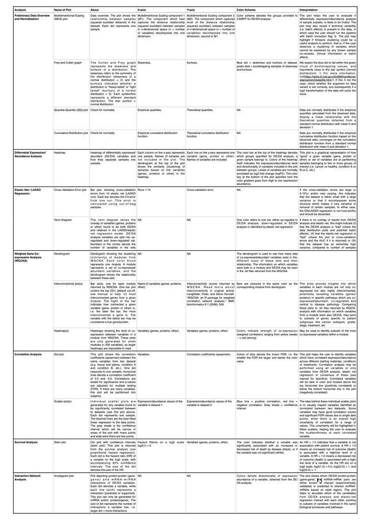

Figure 1

# N-glycan Serum Markers for BC Diagnostics

This section contains an example of how CAMPP is run using different flags in the command-line and what output the user can expect. The files used for running this example may be found in the repository https: //github.com/ELELAB/N-glycan-TIF/tree/master/Data/DataExamples.

The case below uses N-glycans abundances measured using high resolution quantitative Ultra-Performance Liquid Chromatography (UPLC) [28] from interstitial samples [15] and matched serum. Tumor interstitial fluid (TIF), normal interstitial fluid (NIF) and serum samples were collected from 90 women diagnosed with breast cancer (BC). A total of 165 N-glycan groups were identified [32].

Briefly, the involvement of N-glycosylation in development and progression of BC has been documented by both in vitro and in vivo studies [3, 5, 16]. Several circulating N-glycan patterns with altered glycan structures, possibly originating from a primary tumor or from other organs, in response to a neoplastic process, have recently been described in a number of studies by using high-throughput N-glycan profiling [2, 18, 25, 28].